# Análisis de datos de la encuesta de personas

Cristian Bravo Lillo (cristian@bravolillo.xyz)

Último update: Tue Sep 19 12:57:49 2017

## Datos de la muestra

En total, tenemos 743 encuestados, que reportaron tener 765 trabajos. Las siguientes dos tablas muestran la frecuencia de encuestados con y sin magíster, con y sin doctorado, y con y sin postdoctorado.

Tabla 1: Contingencia de MsC, PhDs y Postdocs (%) en mujeres

|  | No tiene Postdoc | Tiene Postdoc | Subtotal |
| --- | --- | --- | --- |
| No tiene MsC, No tiene PhD | 37 | 2 | 39 |
| No tiene MsC, Tiene PhD | 91 | 42 | 133 |
| Tiene MsC, No tiene PhD | 94 | 0 | 94 |
| Tiene MsC, Tiene PhD | 61 | 17 | 78 |
| Subtotal | 283 | 61 | 344 |

Tabla 2: Contingencia de MsC, PhDs y Postdocs (%) en hombres

|  | No tiene Postdoc | Tiene Postdoc | Subtotal |
| --- | --- | --- | --- |
| No tiene MsC, No tiene PhD | 33 | 1 | 34 |
| No tiene MsC, Tiene PhD | 79 | 98 | 177 |
| Tiene MsC, No tiene PhD | 89 | 1 | 90 |
| Tiene MsC, Tiene PhD | 64 | 34 | 98 |
| Subtotal | 265 | 134 | 399 |

## ¿Qué factores influyen en que la persona tenga trabajo?

El siguiente análisis se realizó sólo sobre las personas que declaran residir en Chile (n = 619).

El cuadro siguiente muestra una regresión logística sobre la variable binaria de si la persona tiene trabajo. Las variables de entrada son:

- la edad,
- el género,
- el número de artículos que la persona ha escrito,
- el número de libros que la persona ha escrito,
- el número de proyectos que la persona ha ganado,
- si la persona tiene o no un máster (MsC),
- si la persona tiene o no un doctorado (PhD),
- si la persona tiene o no un postdoctorado.

Los dos factores que influyen significativamente sobre el que la persona tenga trabajo son el número de artículos (aporte.numarticulos), y el que la persona tenga un doctorado (sit.tiene.phd). Ambos factores influyen positivamente sobre el que la persona tenga trabajo.

La regresión anterior no es muy robusta, sin embargo. Se realizó un diagnóstico de la regresión (no mostrado), y existen puntos con una distancia de Cook muy grande (y por tanto con un alto nivel de influencia), pero que no deben ser eliminados porque no son errores.

```
##
## Call:
## glm(formula = ins.tienetrabajo ~ bio.edad + bio.genero + aporte.numarticulos +
##     aporte.numlibros + aporte.numproyectos.gana + sit.tiene.msc +
##     sit.tiene.phd + sit.tiene.pos, family = binomial, data = personas.enchile)
##
## Deviance Residuals:
##     Min       1Q   Median       3Q      Max
## -2.5064   0.2175   0.5467   0.7176   1.2583
##
## Coefficients:
##                          Estimate Std. Error z value Pr(>|z|)
## (Intercept)              -0.04013    0.74063  -0.054  0.95679
## bio.edad                  0.01809    0.02198   0.823  0.41035
## bio.generoMasculino      -0.39910    0.21244  -1.879  0.06029 .
## aporte.numarticulos       0.09819    0.03154   3.113  0.00185 **
## aporte.numlibros          0.01550    0.15577   0.099  0.92076
## aporte.numproyectos.gana  0.08974    0.06698   1.340  0.18032
## sit.tiene.mscTRUE        -0.23746    0.21716  -1.093  0.27419
## sit.tiene.phdTRUE         0.75014    0.25384   2.955  0.00312 **
## sit.tiene.posTRUE        -0.33394    0.30280  -1.103  0.27009
## ---
## Signif. codes:  0 '***' 0.001 '**' 0.01 '*' 0.05 '.' 0.1 ' ' 1
##
## (Dispersion parameter for binomial family taken to be 1)
##
##     Null deviance: 659.38  on 618  degrees of freedom
## Residual deviance: 595.21  on 610  degrees of freedom
## AIC: 613.21
##
## Number of Fisher Scoring iterations: 6
```

El análisis siguiente es similar al anterior, pero sobre la cantidad de trabajos que tiene cada persona. La regresión aquí es lineal ordinaria. La regresión completa no es significativa.

```
##
## Call:
## lm(formula = ins.cuantostrabajos ~ bio.edad + bio.genero + aporte.numarticulos +
##     aporte.numlibros + aporte.numproyectos.gana + sit.tiene.msc +
##     sit.tiene.phd + sit.tiene.pos, data = personas.enchile)
##
## Residuals:
##     Min      1Q  Median      3Q     Max
## -1.4905 -0.1995 -0.0841  0.0897  3.9170
##
## Coefficients:
##                             Estimate  Std. Error t value  Pr(>|t|)
## (Intercept)               0.96034315  0.24133033   3.979 0.0000774 ***
## bio.edad                  0.00295270  0.00707571   0.417     0.677
## bio.generoMasculino      -0.07943842  0.06722837  -1.182     0.238
## aporte.numarticulos       0.00008423  0.00327198   0.026     0.979
## aporte.numlibros          0.05880656  0.04164765   1.412     0.158
## aporte.numproyectos.gana -0.00470599  0.01443230  -0.326     0.744
## sit.tiene.mscTRUE        -0.04973716  0.06993784  -0.711     0.477
## sit.tiene.phdTRUE         0.12104604  0.08115550   1.492     0.136
## sit.tiene.posTRUE        -0.03985626  0.08609082  -0.463     0.644
## ---
## Signif. codes:  0 '***' 0.001 '**' 0.01 '*' 0.05 '.' 0.1 ' ' 1
##
## Residual standard error: 0.8081 on 610 degrees of freedom
## Multiple R-squared:  0.01256,    Adjusted R-squared:  -0.0003895
## F-statistic: 0.9699 on 8 and 610 DF,  p-value: 0.4584
```

## ¿Qué factores influyen en que la persona tenga un trabajo estable?

En el análisis siguiente, se dividieron los valores de la variable “tipo de contrato” en dos:

- Trabajo estable: ‘Contrato a honorarios’, ‘Contrato a plazo fijo’ y ‘Contrato a plazo indefinido’.
- Trabajo no estable: Todo el resto de los valores.

Con esa definición, se realizó una regresión logística sobre el tener un trabajo estable. Las siguientes son las variables de entrada:

- Género,
- Edad,
- Si la persona tiene un máster (MsC),
- Si la persona tiene un doctorado (PhD),
- Si la persona tiene un postdoctorado,
- Si la persona es sostenedor/a de su hogar,
- Cuántos hijos tiene la persona,
- Si era su anhelo el ser académico/a.

De las anteriores, las variables que influyen significativamente sobre el tener un trabajo estable son las siguientes:

- Las personas con postdoctorado (sit.tiene.pos)
- Los hombres (bio.genero=‘Masculino’)
- La edad (bio.edad)

```
##
## Call:
## glm(formula = trabajo.estable ~ bio.genero + bio.edad + sit.tiene.msc +
##     sit.tiene.phd + sit.tiene.pos + bio.essostenedor + bio.cuantoshijos +
##     ins.anhelo.academico, family = binomial, data = continuo)
##
## Deviance Residuals:
##     Min       1Q   Median       3Q      Max
## -2.1822  -1.2738   0.6590   0.8459   1.1577
##
## Coefficients:
##                          Estimate Std. Error z value Pr(>|z|)
## (Intercept)              -1.13211    0.76084  -1.488 0.136759
## bio.generoMasculino       0.43694    0.18920   2.309 0.020920 *
## bio.edad                  0.05034    0.02148   2.344 0.019078 *
## sit.tiene.mscTRUE         0.21909    0.19461   1.126 0.260258
## sit.tiene.phdTRUE        -0.33354    0.22456  -1.485 0.137468
## sit.tiene.posTRUE         0.92117    0.25322   3.638 0.000275 ***
## bio.essostenedorTRUE      0.07851    0.19077   0.412 0.680682
## bio.cuantoshijos         -0.03896    0.11120  -0.350 0.726083
## ins.anhelo.academicoTRUE  0.09135    0.34318   0.266 0.790105
## ---
## Signif. codes:  0 '***' 0.001 '**' 0.01 '*' 0.05 '.' 0.1 ' ' 1
##
## (Dispersion parameter for binomial family taken to be 1)
##
##     Null deviance: 768.75  on 661  degrees of freedom
## Residual deviance: 736.26  on 653  degrees of freedom
##   (3 observations deleted due to missingness)
## AIC: 754.26
##
## Number of Fisher Scoring iterations: 4
```

## ¿Explica el salario recibido la percepción de la inserción?

En el siguiente cuadro se muestra una regresión lineal simple de varios factores sociodemográficos (edad, género, si la persona es sostenedor de su hogar, cuántos hijos tiene, si tiene trabajo, si era su anhelo ser académico) sobre la percepción de inserción. El set de datos es restringido sólo a personas que residen en Chile (la inserción se produce sólo sobre aquellas personas que han vuelto al país), y que poseen alguna percepción de su inserción. No se incluye el ingreso porque las variables “tiene trabajo” e “ingreso” están condicionadas una a la otra.

Se realizó un diagnóstico de la regresión (no mostrado). A pesar de que existen puntos que tienen una influencia muy alta (medida a través de la distancia de Cook, bajo el criterio 4/n), no se eliminaron porque no son errores.

Lo que se puede colegir de la regresión es lo siguiente:

- El tener trabajo (ins.tienetrabajo=TRUE) influye significativa y fuertemente sobre la percepción de inserción: las personas que tienen trabajo tienen una percepción de inserción 1.8 puntos más alta que las personas que no tienen trabajo.
- El ser sostenedor del hogar propio (bio.essostenedor=TRUE) influye significativamente en la percepción de inserción.
- Tanto el número de hijos (bio.cuantoshijos) como el género (bio.genero=‘Masculino’) influyen significativamente sobre la percepción de inserción.
- El modelo completo es significativo (p < 2.2 * 10^-16); sin embargo, explica sólo alrededor del 19% de la variabilidad en la percepción de inserción.

```
##
## Call:
## lm(formula = ins.prom.percepcion ~ bio.edad + bio.genero + bio.essostenedor +
##     bio.cuantoshijos + ins.tienetrabajo + ins.anhelo.academico,
##     data = personas.enchile)
##
## Residuals:
##     Min      1Q  Median      3Q     Max
## -4.0390 -1.2252  0.0899  1.2925  4.6078
##
## Coefficients:
##                          Estimate Std. Error t value Pr(>|t|)
## (Intercept)               2.69903    0.68830   3.921  0.00010 ***
## bio.edad                 -0.01535    0.01790  -0.857  0.39162
## bio.generoMasculino       0.32201    0.16261   1.980  0.04820 *
## bio.essostenedorTRUE      0.50370    0.17120   2.942  0.00341 **
## bio.cuantoshijos          0.23067    0.09452   2.441  0.01500 *
## ins.tienetrabajoTRUE      1.84810    0.20326   9.092  < 2e-16 ***
## ins.anhelo.academicoTRUE -0.30393    0.29962  -1.014  0.31089
## ---
## Signif. codes:  0 '***' 0.001 '**' 0.01 '*' 0.05 '.' 0.1 ' ' 1
##
## Residual standard error: 1.792 on 513 degrees of freedom
##   (99 observations deleted due to missingness)
## Multiple R-squared:  0.2038, Adjusted R-squared:  0.1945
## F-statistic: 21.89 on 6 and 513 DF,  p-value: < 2.2e-16
```

El modelo siguiente analiza la influencia de los mismos factores anteriores, pero sólo para las personas que tienen trabajo; se agregó el ingreso como variable de entrada.

El único factor significativo en este caso es el ingreso (as.numeric(ins.ingreso), que representa el correlativo del tramo de ingreso). El modelo completo es significativo, y explica alrededor del 13% de la variabilidad de la percepción de inserción.

```
##
## Call:
## lm(formula = ins.prom.percepcion ~ bio.edad + bio.genero + bio.essostenedor +
##     bio.cuantoshijos + ins.anhelo.academico + as.numeric(ins.ingreso),
##     data = personas.enchile[personas.enchile$ins.tienetrabajo,
##         ])
##
## Residuals:
##     Min      1Q  Median      3Q     Max
## -4.3371 -1.2222  0.2672  1.2986  3.3780
##
## Coefficients:
##                           Estimate Std. Error t value Pr(>|t|)
## (Intercept)               2.473488   0.790805   3.128  0.00189 **
## bio.edad                 -0.008971   0.019802  -0.453  0.65075
## bio.generoMasculino       0.166891   0.177635   0.940  0.34802
## bio.essostenedorTRUE      0.065973   0.193845   0.340  0.73378
## bio.cuantoshijos          0.131028   0.100845   1.299  0.19458
## ins.anhelo.academicoTRUE -0.252655   0.325709  -0.776  0.43837
## as.numeric(ins.ingreso)   0.622238   0.086700   7.177 3.39e-12 ***
## ---
## Signif. codes:  0 '***' 0.001 '**' 0.01 '*' 0.05 '.' 0.1 ' ' 1
##
## Residual standard error: 1.733 on 408 degrees of freedom
##   (65 observations deleted due to missingness)
## Multiple R-squared:  0.1491, Adjusted R-squared:  0.1366
## F-statistic: 11.92 on 6 and 408 DF,  p-value: 2.447e-12
```

El gráfico 1 muestra la relación entre la percepción de inserción y el nivel de ingreso recibido a través de un boxplot. El hecho de que el grupo de ingreso más alto tenga un promedio de percepción más bajo probablemente no tiene ningún significado especial.

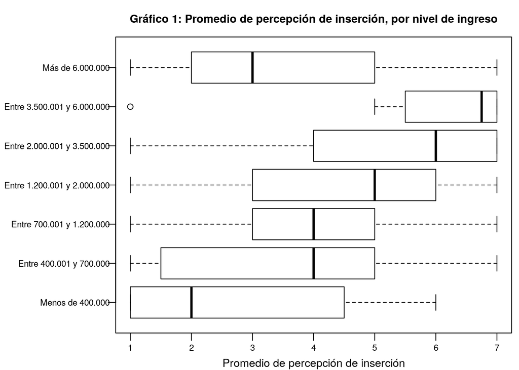